# Análisis scRNA-seq: Efecto de Idasanutlin y Nilotinib en LMC

Authors

Paola Albarrán Godoy

Yael Daniel Hernandez Gonzalez

Published

June 10, 2026

# 1 Descripción del equipo

- **Integrantes:**
  - Paola Albarrán Godoy (palbarrango)
  - Yael Daniel Hernández González (yhernandez)
- **Correos electrónicos de los integrantes:**
  - paolagodyy6@gmail.com
  - yaelhgs@gmail.com

# 2 Descripción de los datos

- **Título del estudio:** Single cell RNA-seq analysis of the effects of idasanutlin and/or nilotinib on primary human CML cells engrafted into the bone marrow of immunocompromised mice
- **Especie:** Homo sapiens.
- **Tejido/tipo celular:** Células humanas CD45⁺ y CD45⁺CD34⁺ aisladas de médula ósea de ratones PDX (xenoinjertos derivados de pacientes con CML en fase crónica o blástica)
- **Número de acceso GEO:** GSE218185
- **Tipo de experimento:** scRNA-seq (Expression profiling by high throughput sequencing).
- **Secuenciador:** Illumina HiSeq4000, Illumina NovaSeq 6000
- **Química/protocolo:** 10X Chromium Single Cell 3’ gene expression library (kit v2) y 5’ gene expression library (kit v1)
- **Tipo de captura:** Captura en gotas con microfluidics (Chromium Controller, 10X Genomics) — Single Cell A Chip
- **Numero estimado de células recuperadas por muestras:** 13,873 células en total distribuidas en 9 muestras, provenientes de 2 cohortes (COH4 y COH5) y 3 condiciones de tratamiento: Vehicle (6,080), Nilotinib (3,368) y NIL+IDASA (4,425).
- **Profundidad:** Mínimo 40,000 reads por célula
- **Artículo relacionado:** Scott MT, Liu W, Mitchell R, Clarke CJ et al. Activating p53 abolishes self-renewal of quiescent leukaemic stem cells in residual CML disease. Nat Commun 2024 Jan 22;15(1):651. PMID:38246924

# 3 Abstract

# 4 Diseño experimental

Se empleó un modelo in vivo de xenoinjerto derivado de paciente (**PDX**). Para ello, se utilizaron ratones inmunodeprimidos (**NSG/NRG**) injertados con células primarias de LMC (**CD34+, p53 WT**). Posteriormente, el análisis de la respuesta al tratamiento, se hizo mediante scRNA-seq en células **(huCD45+ o huCD34+**) aisladas de su médula ósea.

La respuesta al tratamiento se evaluó comparando los siguientes grupos:

1. **Vehículo (VEH):** Grupo control sin fármacos activos.
2. **Nilotinib (NIL):** Tratamiento exclusivo con TKI durante 28 días.
3. **Nilotinib + Idasanutlin (NIL+IDASA):** Tratamiento combinado donde se administró NIL (TKI) junto con IDASA. *Nota: Tras la fase de tratamiento, los animales entraron en un periodo libre de fármacos de 28 días para evaluar el agotamiento a largo plazo de las LSC.*

   Aunque el estudio utilizó una cohorte total de 46 ratones para análisis de citometría (26 en COH4 y 20 en COH5), el análisis de **scRNA-seq** se centró en una selección representativa de réplicas biológicas:
4. **Cohorte 4 (fin del tratamiento):** Las células se recolectaron inmediatamente tras finalizar los 28 días de tratamiento. Para el análisis de scRNA-seq se seleccionaron un total de **6 muestras**.
5. **Cohorte 5 (periodo libre de tratamiento):** Se procesaron **3 muestras** adicionales para el analisis de scRNA-seq, para representar la persistencia de las células troncales.

# 5 Flujo de trabajo

El flujo de trabajo de este proyecto se diseñó en dos entornos computacionales distintos. El intento de procesamiento primario a partir de los datos crudos de secuenciación (archivos FASTQ) se configuró en el cluster. Debido a la limitación de los datos públicos (ausencia del R1), todo el análisis *downstream* posterior a la obtención de las matrices de conteos preprocesadas por Cell Ranger fue corrido en un entorno local.

## 5.1 Entorno de Clúster (Procesamiento primario)

Los *scripts* correspondientes a la descarga de datos, obtención del genoma de referencia y el intento de alineamiento con Cell Ranger mediante contenedores Singularity se almacenaron en la siguiente ruta del clúster:

`Ruta: /mnt/data/transcriptomica/palbarrango/BioProject_scRNA/`

**Estructura de directorios en el clúster:**

```
BioProject_scRNA/
├── data/
│   └── fastq/                         # FASTQs descargados desde SRA (21 SRRs, ~466 GB)
├── reference/
│   ├── cellranger_7.2.0.sif           # Imagen Singularity de Cell Ranger
│   └── refdata-gex-GRCh38-2020-A/     # Genoma de referencia GRCh38 (GENCODE v32)
└── scripts/
    ├── 01_download_fastq.sh           # Descarga de FASTQs con prefetch/fasterq-dump
    ├── 02_download_reference.sh       # Descarga del genoma de referencia
    ├── 03_pull_cellranger.sh          # Descarga de imagen Singularity
    ├── 04_run_cellranger.sh           # Alineamiento y cuantificación con Cell Ranger
    └── logs/                          # Logs de los jobs SLURM
```

## 5.2 Entorno Local (Análisis *downstream* con Seurat)

A partir de las matrices descargadas de GEO, el filtrado, reducción de dimensionalidad, *clustering* y análisis de expresión diferencial se ejecutaron en local, generando la siguiente estructura de resultados:

**Estructura de directorios en local:**

```
BioProject_scRNA/ (local)
├── output/
│   └── GSE218185_CML_normalized.rds   # Objeto Seurat post-QC y normalización
├── seurat_objects/
│   └── GSE218185_CML_anotado.rds      # Objeto Seurat final con anotación celular
├── markers_results/
│   └── markers_por_cluster.csv        # Marcadores identificados con FindAllMarkers
└── DEG_results/
    ├── DEG_CD34_NIL_IDASA_vs_VEH.csv    # DEGs poblacion CD34+ completa
    ├── GO_UP_NIL_IDASA.csv              # Enriquecimiento GO-BP de genes UP
    └── GO_DOWN_NIL_IDASA.csv            # Enriquecimiento GO-BP de genes DOWN
```

## 5.3 Pipeline

```
Matrices Cell Ranger (barcodes + features + matrix por GSM)
         ↓
    Read10X() + CreateSeuratObject()   [min.cells=3, min.features=200]
         ↓
    merge() → objeto unificado (9 muestras)
         ↓
  PercentageFeatureSet() → percent_mito / percent_ribo / percent_hb
         ↓
  VlnPlot() + FeatureScatter() → visualización QC
         ↓
  subset() → filtrado (200 < nFeature < 6000; mito < 20%; ribo < 50%)
         ↓
  Exploración top genes + MALAT1
         ↓
  NormalizeData() → log(CP10K)        [método: LogNormalize, scale.factor=10000]
         ↓
  FindVariableFeatures() → 2000 HVG   [método: vst]
         ↓
  ScaleData()
         ↓
  RunPCA() → 50 PCs
         ↓
  RunHarmony() → corrección de lote por experimento (EXPT1/2/3)
         ↓
  RunUMAP() → 25 dims de Harmony
         ↓
  FindNeighbors() + FindClusters()    [k=20, resolución=0.5, Louvain]
         ↓
  FindAllMarkers() → marcadores por cluster (Wilcoxon, logFC > 0.25)
         ↓
  Anotación manual de tipos celulares (ESC-REG / NMM / ME / EBM)
         ↓
 FindMarkers() → DEG: NIL+IDASA vs VEH en células CD34+
         ↓
  Volcano plot + tabla de DEGs significativos
         ↓
  enrichGO() → enriquecimiento GO-BP (clusterProfiler) — UP y DOWN
         ↓
  saveRDS() → objeto final anotado
```

# 6 Obtención de datos y procesamiento con Cell Ranger

## 6.1 Intento de procesamiento desde datos crudos (FASTQs)

Con el objetivo de seguir el pipeline completo de análisis de scRNA-seq desde los datos crudos, se intentó reprocesar los archivos FASTQ del dataset GSE218185 utilizando Cell Ranger 7.2.0 (10X Genomics).  
Los 21 archivos SRR correspondientes a las 9 muestras del BioProject PRJNA902697 fueron identificados mediante el SRA Run Selector de NCBI y descargados utilizando las herramientas `prefetch` y `fasterq-dump`. Dado que Cell Ranger no estaba disponible como módulo en el cluster, se utilizó un contenedor Singularity. El genoma de referencia utilizado fue GRCh38 con la anotación GENCODE v32, que corresponde a la versión utilizada en el paper original.

## 6.2 Datos crudos incompletos en repositorios públicos

Posteriormente de la descarga de los archivos se identificó que todos los SRRs contenían un solo archivo FASTQ sin sufijo numérico (`SRR22321154.fastq.gz`) con reads de longitud de 98-99 bp, en lugar de los dos archivos esperados `_1.fastq.gz` (R1: barcode + UMI, 28 bp) y `_2.fastq.gz` (R2: cDNA, 98 bp), los cuales son esenciales por Cell Ranger.

Dado a la problemática que se presentó, se realizó lo siguiente:

- Retrocedimos a la descarga de los 21 SRRs, forzando obtener los archivos esperados `_1.fastq.gz y _2.fastq.gz`
- Se inspeccionó la longitud y contenido de los reads.
- Se consultó los metadatos en NCBI SRA.
- Se consultó la base de datos European Nucleotide Archive (ENA).

Sin embargo, nos percatamos que los autores depositaron únicamente el read de cDNA (R2) en los repositorios públicos, omitiendo el read de barcode+UMI (R1), y para el propósito de esta práctica resulta imposible la reproducción del pipeline completo desde los datos crudos, ya que sin R1 no es posible asignar reads a células individuales ni recuantificar UMIs.

## 6.3 Decisión metodológica: uso de matrices procesadas de GEO

Dado que el R1 no está disponible en ningún repositorio público, el análisis posterior se realizó a partir de las matrices de conteos procesadas depositadas por los autores en GEO (`GSE218185_RAW.tar`). Estas matrices en formato 10X Genomics (barcodes.tsv.gz, features.tsv.gz, matrix.mtx.gz) equivalente al resultado que se habría obtenido al correr Cell Ranger sobre los FASTQs completos.

# 7 Definir estructura de muestras

Cada muestra GSM tiene su propia carpeta con los tres archivos de 10X Genomics

1. `barcodes.tsv.gz:` Contiene los identificadores únicos correspondientes a cada célula capturada. Definirá los nombres de las **columnas** de la matriz de expresión.
2. `features.tsv.gz:` Contiene la lista de todos los genes anotados. Este archivo define los nombres de las **filas** de la matriz de expresión.
3. `matrix.mtx.gz`: Contiene los valores numéricos crudos, es decir, la cantidad exacta de transcritos (UMIs) que se detectaron para cada gen dentro de cada célula.

Como anteriormente se mencionó, el diseño tiene **3 condiciones experimentales** (VEH, NIL, NIL+IDASA), junto con **2 estrategias de aislamiento** (CD45+, CD34+) para capturar distintos niveles de resolución biológica.

- **huCD45+** nos permite ver el **panorama completo** del sistema hematopoyético humano: células maduras mieloides, progenitores y LSC al mismo tiempo.
- **huCD34+** es un marcador de células progenitoras primitivas que enriquece específicamente para las **células madre leucémicas (LSC)** y progenitores tempranos.´

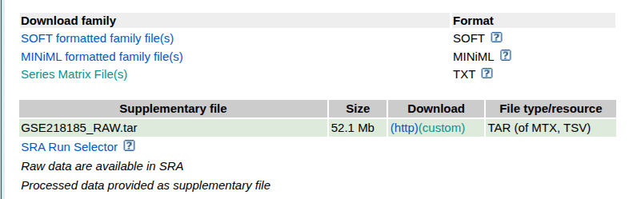

  Información suplementaria encontrada en GEO para el GSE218185.

```r
library(Matrix)
library(Seurat)        # Principal para análisis de scRNA-seq
library(dplyr)
library(ggplot2)
library(patchwork)     # Combinar gráficos
library(DoubletFinder)

base_dir <- "~/Documents/TranscriptomicaDifrencial_Opt/BioProject_scRNA/data"
# Tres experimentos de captura scRNA-seq:
#   EXPT1: células huCD45+ (panorama completo)
#   EXPT2: células huCD34+ de COH4 (LSC enriquecidas)
#   EXPT3: células huCD34+ de COH4 y COH5

muestras <- list(
  # EXPT1: huCD45+ — COH4
  # VEH, NIL+IDASA
  "COH4_EXPT1_VEH_CD45"       = file.path(base_dir, "GSM6736197"),
  "COH4_EXPT1_NIL_IDASA_CD45" = file.path(base_dir, "GSM6736198"),

  # EXPT2: huCD34+ — COH4
  # VEH, NIL, NILNIL+IDASA
  "COH4_EXPT2_VEH_CD34"       = file.path(base_dir, "GSM6736199"),
  "COH4_EXPT2_NIL_CD34"       = file.path(base_dir, "GSM6736200"),
  "COH4_EXPT2_NIL_IDASA_CD34" = file.path(base_dir, "GSM6736201"),

  # EXPT3: huCD34+ — COH4 y COH5
  # GSM6736202: COH4 VEH
  # GSM6736203-205: COH5 VEH, NIL, NILNIL+IDASA
  "COH4_EXPT3_VEH_CD34"       = file.path(base_dir, "GSM6736202"),
  "COH5_EXPT3_VEH_CD34"       = file.path(base_dir, "GSM6736203"),
  "COH5_EXPT3_NIL_CD34"       = file.path(base_dir, "GSM6736204"),
  "COH5_EXPT3_NIL_IDASA_CD34" = file.path(base_dir, "GSM6736205")
)

# Verificar que todas mis carpetas estén completas
for (nombre in names(muestras)) {
  if (dir.exists(muestras[[nombre]])) {
    message("encontrada: ", nombre, " -> ", muestras[[nombre]])
  } else {
    warning("no encontrada: ", nombre, " -> ", muestras[[nombre]])
  }
}
```

```
encontrada: COH4_EXPT1_VEH_CD45 -> ~/Documents/TranscriptomicaDifrencial_Opt/BioProject_scRNA/data/GSM6736197
```

```
encontrada: COH4_EXPT1_NIL_IDASA_CD45 -> ~/Documents/TranscriptomicaDifrencial_Opt/BioProject_scRNA/data/GSM6736198
```

```
encontrada: COH4_EXPT2_VEH_CD34 -> ~/Documents/TranscriptomicaDifrencial_Opt/BioProject_scRNA/data/GSM6736199
```

```
encontrada: COH4_EXPT2_NIL_CD34 -> ~/Documents/TranscriptomicaDifrencial_Opt/BioProject_scRNA/data/GSM6736200
```

```
encontrada: COH4_EXPT2_NIL_IDASA_CD34 -> ~/Documents/TranscriptomicaDifrencial_Opt/BioProject_scRNA/data/GSM6736201
```

```
encontrada: COH4_EXPT3_VEH_CD34 -> ~/Documents/TranscriptomicaDifrencial_Opt/BioProject_scRNA/data/GSM6736202
```

```
encontrada: COH5_EXPT3_VEH_CD34 -> ~/Documents/TranscriptomicaDifrencial_Opt/BioProject_scRNA/data/GSM6736203
```

```
encontrada: COH5_EXPT3_NIL_CD34 -> ~/Documents/TranscriptomicaDifrencial_Opt/BioProject_scRNA/data/GSM6736204
```

```
encontrada: COH5_EXPT3_NIL_IDASA_CD34 -> ~/Documents/TranscriptomicaDifrencial_Opt/BioProject_scRNA/data/GSM6736205
```

# 8 Leer los datos con Read10X y crear objetos Seurat

A diferencia del trabajo en clase, en donde ya teníamos una sola matriz consolidada de todo el estudio, aquí leeremos cada muestra por separado porque cada GSM es un experimento independiente de captura celular.

Es importante mantener la identidad de cada muestra para hacer las comparaciones entre condiciones (VEH vs NIL+IDASA) y detectar posibles efectos batch.

**Nota sobre el formato HDF5:**

En la Práctica 1 fue necesario crear archivos HDF5 (.h5) como paso intermedio porque los datos del estudio venían en una única matriz consolidada para todos los pacientes, y era necesario separarlos por muestra antes de poder crear los objetos Seurat individuales.

Sin embargo, en este caso no necesario porque los datos fueron descargados en el formato estándar de Cell Ranger: como anteriormente se mencionó, existe una carpeta independiente por muestra (GSM), cada una conteniendo sus propios archivos barcodes.tsv.gz, features.tsv.gz y matrix.mtx.gz. Y, con ayuda de la función Read10X() de Seurat es posible leer esta estructura directamente y producir exactamente la misma matriz de conteos que produciría Read10X_h5() si los datos estuvieran en formato HDF5. Por lo tanto, ambos flujos son equivalentes en resultado.

```r
# Leer cada muestra y para cada una crear su objeto seurat
seurat_list <- list()

for (nombre in names(muestras)) {
  ruta <- muestras[[nombre]]

  message("cargando muestra: ", nombre)

  # Leer los tres archivos
  counts <- Read10X(data.dir = ruta)

  # Crear objeto Seurat con los mismos umbrales que vimos en clase, donde:
  # min.cells = 3: un gen debe estar en al menos 3 células para incluirse
  # min.features = 200: una célula debe tener al menos 200 genes detectados
  sobj <- CreateSeuratObject(
    counts       = counts,
    project      = nombre,
    min.cells    = 3,
    min.features = 200
  )

  # --- Metadatos de tratamiento ---
  # Las 3 condiciones del diseño experimental, asegurarnos de mantener la
  # identidad
  if (grepl("VEH", nombre)) {
    sobj$condition <- "Vehicle"
  } else if (grepl("NIL_IDASA", nombre)) {
    sobj$condition <- "NIL_IDASA"
  } else if (grepl("NIL", nombre)) {
    sobj$condition <- "Nilotinib"
  }

  # --- Tipo de población celular aislada ---
  # CD45+: panorama completo de células humanas (EXPT1)
  # CD34+: progenitores/LSC enriquecidas (EXPT2 y EXPT3)
  sobj$cell_type <- ifelse(grepl("CD45", nombre), "huCD45", "huCD34")

  # --- Cohorte de pacientes ---
  # COH4 y COH5 — importante para controlar variabilidad
  sobj$cohort <- ifelse(grepl("COH4", nombre), "COH4", "COH5")

  # --- Experimento de captura ---
  # EXPT1, EXPT2, EXPT3 capturas independientes
  # IMPORTANTE para detectar efectos batch
  sobj$experiment <- sub(".*_(EXPT[0-9])_.*", "\\1", nombre)

  message("  -> ", ncol(sobj), " células, ", nrow(sobj), " genes")
  seurat_list[[nombre]] <- sobj
}
```

# 9 Métricas de calidad crudas de Cell Ranger

Los **genes mitocondriales** `MT-`, son los que nos indican si una célula está dañada o en apoptosis. En el estudio se excluyen a células con >20% de contenido mitocondrial en las células huCD45+ de PDX.

Los **genes ribosomales** `^RP[SL]`, en este caso resultan ser relevantes en LMC porque en el estudió se observó upregulation de genes de proteínas ribosomales en LSC quiescentes (ESC-REGlow), lo que conecta con pluripotencia de células ES.

Los **genes de hemoglobina** (`^HB`) dado a que las células de LSC humanas se aislaron de PDX es posible que haya ARN murino. Un alto porcentaje nos puede indicar contaminación.

```r
for (nombre in names(seurat_list)) {

  # --- Genes mitocondriales ---
  seurat_list[[nombre]] <- PercentageFeatureSet(
    seurat_list[[nombre]],
    pattern  = "^MT-",
    col.name = "percent_mito"
  )

  # --- Genes ribosomales ---
  #  LSC quiescentes tienen alta expresión ribosomal
  seurat_list[[nombre]] <- PercentageFeatureSet(
    seurat_list[[nombre]],
    pattern  = "^RP[SL]",
    col.name = "percent_ribo"
  )

  # --- Genes de hemoglobina ---
  seurat_list[[nombre]] <- PercentageFeatureSet(
    seurat_list[[nombre]],
    pattern  = "^HB[^(P|E|S)]",
    col.name = "percent_hb"
  )
}

# Visualizar resumen de QC para muestra 1
head(seurat_list[[1]]@meta.data)
```

|  | orig.ident | nCount_RNA | nFeature_RNA | condition | cell_type | cohort | experiment | percent_mito | percent_ribo | percent_hb |
| --- | --- | --- | --- | --- | --- | --- | --- | --- | --- | --- |
| AAACCTGAGTGGTCCC-1 | COH4_EXPT1_VEH_CD45 | 5547 | 1845 | Vehicle | huCD45 | COH4 | EXPT1 | 6.4178835 | 7.175050 | 0.0000000 |
| AAACCTGCAGTCGTGC-1 | COH4_EXPT1_VEH_CD45 | 4245 | 1667 | Vehicle | huCD45 | COH4 | EXPT1 | 9.0223793 | 18.987044 | 0.0000000 |
| AAACCTGGTCAGCTAT-1 | COH4_EXPT1_VEH_CD45 | 13738 | 682 | Vehicle | huCD45 | COH4 | EXPT1 | 0.1674188 | 4.498471 | 76.3502693 |
| AAACCTGGTCTGCAAT-1 | COH4_EXPT1_VEH_CD45 | 6100 | 2034 | Vehicle | huCD45 | COH4 | EXPT1 | 7.2295082 | 13.475410 | 0.0000000 |
| AAACCTGTCTCGCTTG-1 | COH4_EXPT1_VEH_CD45 | 4560 | 286 | Vehicle | huCD45 | COH4 | EXPT1 | 0.0877193 | 1.140351 | 85.7236842 |
| AAACCTGTCTGGGCCA-1 | COH4_EXPT1_VEH_CD45 | 1750 | 905 | Vehicle | huCD45 | COH4 | EXPT1 | 0.2285714 | 23.028571 | 0.1142857 |

# 10 Fusionar todos los objetos en uno solo

Para poder hacer un control de calidad y visualización comparativa entre las condiciones experimentales, fusionamos todas las muestras en un único objeto Seurat.

```r
# primer objeto es la "base", los demás se añaden
primer_objeto <- seurat_list[[1]]
resto_objetos  <- seurat_list[-1]

alldata <- merge(
  x           = primer_objeto,
  y           = resto_objetos,
  add.cell.ids = names(seurat_list),  # se agrega prefijo del nombre de muestra a cada barcode
  project     = "GSE218185_CML"
)

# Limpiar memoria
rm(seurat_list, primer_objeto, resto_objetos)
gc()
```

```
           used  (Mb) gc trigger  (Mb) max used  (Mb)
Ncells  3763829 201.1    6895831 368.3  5692668 304.1
Vcells 33638085 256.7   65317334 498.4 65316764 498.4
```

```r
# Verificar el objeto fusionado
alldata
```

```
An object of class Seurat
17861 features across 13873 samples within 1 assay
Active assay: RNA (17861 features, 0 variable features)
 9 layers present: counts.COH4_EXPT1_VEH_CD45, counts.COH4_EXPT1_NIL_IDASA_CD45, counts.COH4_EXPT2_VEH_CD34, counts.COH4_EXPT2_NIL_CD34, counts.COH4_EXPT2_NIL_IDASA_CD34, counts.COH4_EXPT3_VEH_CD34, counts.COH5_EXPT3_VEH_CD34, counts.COH5_EXPT3_NIL_CD34, counts.COH5_EXPT3_NIL_IDASA_CD34
```

Visualizar la metadata:

```r
head(alldata@meta.data, 10)
```

|  | orig.ident | nCount_RNA | nFeature_RNA | condition | cell_type | cohort | experiment | percent_mito | percent_ribo | percent_hb |
| --- | --- | --- | --- | --- | --- | --- | --- | --- | --- | --- |
| COH4_EXPT1_VEH_CD45_AAACCTGAGTGGTCCC-1 | COH4_EXPT1_VEH_CD45 | 5547 | 1845 | Vehicle | huCD45 | COH4 | EXPT1 | 6.41788354 | 7.1750496 | 0.0000000 |
| COH4_EXPT1_VEH_CD45_AAACCTGCAGTCGTGC-1 | COH4_EXPT1_VEH_CD45 | 4245 | 1667 | Vehicle | huCD45 | COH4 | EXPT1 | 9.02237927 | 18.9870436 | 0.0000000 |
| COH4_EXPT1_VEH_CD45_AAACCTGGTCAGCTAT-1 | COH4_EXPT1_VEH_CD45 | 13738 | 682 | Vehicle | huCD45 | COH4 | EXPT1 | 0.16741884 | 4.4984714 | 76.3502693 |
| COH4_EXPT1_VEH_CD45_AAACCTGGTCTGCAAT-1 | COH4_EXPT1_VEH_CD45 | 6100 | 2034 | Vehicle | huCD45 | COH4 | EXPT1 | 7.22950820 | 13.4754098 | 0.0000000 |
| COH4_EXPT1_VEH_CD45_AAACCTGTCTCGCTTG-1 | COH4_EXPT1_VEH_CD45 | 4560 | 286 | Vehicle | huCD45 | COH4 | EXPT1 | 0.08771930 | 1.1403509 | 85.7236842 |
| COH4_EXPT1_VEH_CD45_AAACCTGTCTGGGCCA-1 | COH4_EXPT1_VEH_CD45 | 1750 | 905 | Vehicle | huCD45 | COH4 | EXPT1 | 0.22857143 | 23.0285714 | 0.1142857 |
| COH4_EXPT1_VEH_CD45_AAACGGGAGAGTAATC-1 | COH4_EXPT1_VEH_CD45 | 817 | 575 | Vehicle | huCD45 | COH4 | EXPT1 | 2.20318237 | 0.3671971 | 0.1223990 |
| COH4_EXPT1_VEH_CD45_AAACGGGAGCCACGCT-1 | COH4_EXPT1_VEH_CD45 | 15791 | 2019 | Vehicle | huCD45 | COH4 | EXPT1 | 0.09499082 | 19.8784118 | 38.4079539 |
| COH4_EXPT1_VEH_CD45_AAACGGGCATCACCCT-1 | COH4_EXPT1_VEH_CD45 | 2291 | 1022 | Vehicle | huCD45 | COH4 | EXPT1 | 7.98777826 | 19.0746399 | 0.0000000 |
| COH4_EXPT1_VEH_CD45_AAACGGGGTTGCGCAC-1 | COH4_EXPT1_VEH_CD45 | 668 | 423 | Vehicle | huCD45 | COH4 | EXPT1 | 9.13173653 | 11.5269461 | 0.0000000 |

¿Cuántas células hay por muestra?

```r
table(alldata$orig.ident)
```

```
COH4_EXPT1_NIL_IDASA_CD45       COH4_EXPT1_VEH_CD45       COH4_EXPT2_NIL_CD34
                     1112                      1369                       542
COH4_EXPT2_NIL_IDASA_CD34       COH4_EXPT2_VEH_CD34       COH4_EXPT3_VEH_CD34
                      394                       350                      2750
      COH5_EXPT3_NIL_CD34 COH5_EXPT3_NIL_IDASA_CD34       COH5_EXPT3_VEH_CD34
                     2826                      2919                      1611
```

¿Cuántas células hay por condición?

```r
table(alldata$condition)
```

```
NIL_IDASA Nilotinib   Vehicle
     4425      3368      6080
```

# 11 Visualización gráfica del QC

La visualización gŕafica del QC para evaluar la viabilidad celular y la calidad de secuenciación, usaremos `split.by = "condition"` para comparar las 3 condiciones de tratamiento.

Este paso es muy importante porque:

1. La calidad puede variar según el injerto.
2. El tratamiento con NIL+IDASA puede inducir apoptosis, por lo que, elevaría el porcentaje mitocondrial (sin embargo, es importante distinguirlo de los artefactos)

**Violinplots**

- nFeature_RNA y nCount_RNA

- percent_mito

- percent_hb

Algunas muestras contienen subpoblaciones celulares donde la expresión de genes de hemoglobina constituye casi el 100% de sus transcritos.Esto es una señal de alerta, ya que podría indicar contaminación por eritrocitos dado que las células humanas fueron extraídas directamente de la médula ósea de los ratones PDX.

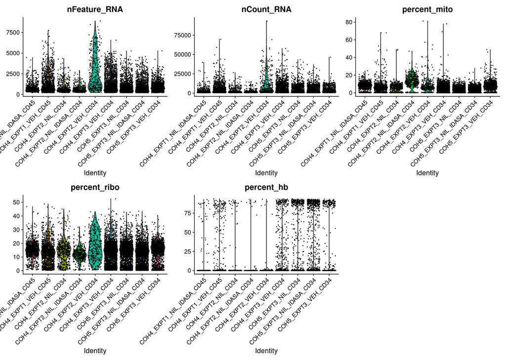

**Figura 1**.Distribución de las métricas de control de calidad (QC).Los gráficos de violín muestran la distribución de cinco parámetros técnicos en las 9 réplicas biológicas del estudio.

```r
feats <- c("nFeature_RNA", "nCount_RNA", "percent_mito", "percent_ribo", "percent_hb")

VlnPlot(
  alldata,
  group.by = "orig.ident",
  features = feats,
  pt.size  = 0.1,
  ncol     = 3
)
```

**Scatter plots**

El gráfico de dispersión confirma la relación entre las métricas de secuenciación. Se puede observar una correlación negativa débil (**-0.27**) entre el porcentaje mitocondrial y los conteos totales, donde las gotas con muy pocos transcritos suelen ser restos celulares. Por otro lado, se observa una correlación positiva (**0.81**) entre `nCount_RNA` y `nFeature_RNA`, lo cual significa que existe una relación entre el número de moléculas de ARN que se capturaron y cuántos genes distintos se detectaron.

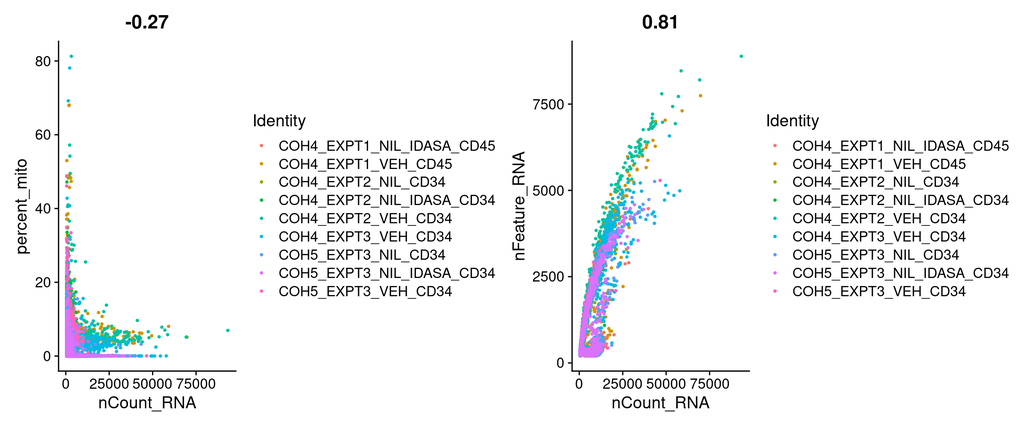

**Figura 2**.Correlación empírica entre las métricas de secuenciación.Gráficos de dispersión (FeatureScatter) que evalúan la relación bidimensional de las métricas de QC en la población total de células.

```r
# nCount vs percent_mito: células con muchos conteos pero alto % mito son sospechosas
plot1 <- FeatureScatter(
  alldata,
  feature1 = "nCount_RNA",
  feature2 = "percent_mito",
  group.by = "orig.ident",
  pt.size  = 0.5
)

# nCount vs nFeature: correlación esperada — si una célula tiene muchos UMIs,
# debería tener muchos genes distintos.
plot2 <- FeatureScatter(
  alldata,
  feature1 = "nCount_RNA",
  feature2 = "nFeature_RNA",
  group.by = "orig.ident",
  pt.size  = 0.5
)

plot1 + plot2
```

Número de células **ANTES** del filtrado:

```r
cat("Total de células antes del filtrado:", ncol(alldata), "\n")
```

```
Total de células antes del filtrado: 13873
```

```r
table(alldata$orig.ident)
```

```
COH4_EXPT1_NIL_IDASA_CD45       COH4_EXPT1_VEH_CD45       COH4_EXPT2_NIL_CD34
                     1112                      1369                       542
COH4_EXPT2_NIL_IDASA_CD34       COH4_EXPT2_VEH_CD34       COH4_EXPT3_VEH_CD34
                      394                       350                      2750
      COH5_EXPT3_NIL_CD34 COH5_EXPT3_NIL_IDASA_CD34       COH5_EXPT3_VEH_CD34
                     2826                      2919                      1611
```

# 12 Filtrado de células de baja calidad

Los umbrales de filtrado están basados en:

1. **`nFeature_RNA > 200`**: Elimina “células” vacías o droplets vacíos.
2. **`nFeature_RNA < 6000`**: Elimina dobletes (dos células capturadas juntas tienen el doble de genes). Específicamente para este análisis, al trabajar con **células de médula ósea** (progenitores hematopoyéticos CD34+ y LSC), suelen ser transcriptomicamente más complejas y en estados de diferenciación temprana se activan muchos programas genéticos simultáneamente. Por esta razón, usar 2,500 como límite eliminaría células biológicamente reales, ya que, por ejemplo un progrenitor CD34+ puede expresar entre 3,000 y 5,000 genes detectables.
3. **`percent_mito < 20`**: En el estudio se usó >20% de contenido mitocondrial como criterio de exclusión para células huCD45+/huCD34+ en PDX.
4. **`percent_ribo < 50`**: Las LSC quiescentes tienen alta expresión de genes ribosomales, entonces un umbral bajo podría eliminar células biológicamente relevantes. Usamos 50% para conservar estas poblaciones.

```r
data.filt <- subset(
  alldata,
  subset = nFeature_RNA > 200 &
           nFeature_RNA < 6000 &
           percent_mito < 20  &
           percent_ribo < 50
)

cat("Células ANTES del filtrado:", ncol(alldata), "\n")
```

```
Células ANTES del filtrado: 13873
```

```r
cat("Células DESPUÉS del filtrado:", ncol(data.filt), "\n")
```

```
Células DESPUÉS del filtrado: 13647
```

```r
cat("Células eliminadas:", ncol(alldata) - ncol(data.filt), "\n\n")
```

```
Células eliminadas: 226
```

```r
# Células por muestra después del filtrado
table(data.filt$orig.ident)
```

```
COH4_EXPT1_NIL_IDASA_CD45       COH4_EXPT1_VEH_CD45       COH4_EXPT2_NIL_CD34
                     1107                      1325                       540
COH4_EXPT2_NIL_IDASA_CD34       COH4_EXPT2_VEH_CD34       COH4_EXPT3_VEH_CD34
                      341                       285                      2736
      COH5_EXPT3_NIL_CD34 COH5_EXPT3_NIL_IDASA_CD34       COH5_EXPT3_VEH_CD34
                     2824                      2915                      1574
```

Visualizar el objeto filtrado:

```r
data.filt
```

```
An object of class Seurat
17861 features across 13647 samples within 1 assay
Active assay: RNA (17861 features, 0 variable features)
 9 layers present: counts.COH4_EXPT1_VEH_CD45, counts.COH4_EXPT1_NIL_IDASA_CD45, counts.COH4_EXPT2_VEH_CD34, counts.COH4_EXPT2_NIL_CD34, counts.COH4_EXPT2_NIL_IDASA_CD34, counts.COH4_EXPT3_VEH_CD34, counts.COH5_EXPT3_VEH_CD34, counts.COH5_EXPT3_NIL_CD34, counts.COH5_EXPT3_NIL_IDASA_CD34
```

Tenemos 17,861 genes detectados en 13,647 células.

Ver metadata filtrada:

```r
head(data.filt@meta.data, 5)
```

|  | orig.ident | nCount_RNA | nFeature_RNA | condition | cell_type | cohort | experiment | percent_mito | percent_ribo | percent_hb |
| --- | --- | --- | --- | --- | --- | --- | --- | --- | --- | --- |
| COH4_EXPT1_VEH_CD45_AAACCTGAGTGGTCCC-1 | COH4_EXPT1_VEH_CD45 | 5547 | 1845 | Vehicle | huCD45 | COH4 | EXPT1 | 6.4178835 | 7.175050 | 0.00000 |
| COH4_EXPT1_VEH_CD45_AAACCTGCAGTCGTGC-1 | COH4_EXPT1_VEH_CD45 | 4245 | 1667 | Vehicle | huCD45 | COH4 | EXPT1 | 9.0223793 | 18.987044 | 0.00000 |
| COH4_EXPT1_VEH_CD45_AAACCTGGTCAGCTAT-1 | COH4_EXPT1_VEH_CD45 | 13738 | 682 | Vehicle | huCD45 | COH4 | EXPT1 | 0.1674188 | 4.498471 | 76.35027 |
| COH4_EXPT1_VEH_CD45_AAACCTGGTCTGCAAT-1 | COH4_EXPT1_VEH_CD45 | 6100 | 2034 | Vehicle | huCD45 | COH4 | EXPT1 | 7.2295082 | 13.475410 | 0.00000 |
| COH4_EXPT1_VEH_CD45_AAACCTGTCTCGCTTG-1 | COH4_EXPT1_VEH_CD45 | 4560 | 286 | Vehicle | huCD45 | COH4 | EXPT1 | 0.0877193 | 1.140351 | 85.72368 |

¿Qué capas (layers) tenemos disponibles?

```r
Layers(data.filt, assay = "RNA")
```

```
[1] "counts.COH4_EXPT1_VEH_CD45"       "counts.COH4_EXPT1_NIL_IDASA_CD45"
[3] "counts.COH4_EXPT2_VEH_CD34"       "counts.COH4_EXPT2_NIL_CD34"
[5] "counts.COH4_EXPT2_NIL_IDASA_CD34" "counts.COH4_EXPT3_VEH_CD34"
[7] "counts.COH5_EXPT3_VEH_CD34"       "counts.COH5_EXPT3_NIL_CD34"
[9] "counts.COH5_EXPT3_NIL_IDASA_CD34"
```

# 13 Exploración de genes más abundantes

Para comprender la dinámica transcripcional de nuestras muestras antes de realizar cualquier agrupamiento celular, es importante hacer una exploración global de los genes que dominan el transcriptoma, para posteriormente hacer una exploración dirigida hacia alguna firma molecular específica reportada de esta enfermedad.

## 13.1 ¿Cuántas lecturas totales tiene cada gen en cada dataset?

```r
# 1. Obtenemos el nombre de todas las capas en el assay "RNA"
capas_disponibles <- Layers(data.filt, assay = "RNA")

# Filtramos y unicamentenos quedamos con las capas de conteos puros ("counts")
capas_conteos <- capas_disponibles[grepl("counts", capas_disponibles)]

# 2. Extraemos la matriz de cada capa (preserva los rownames correctos)
cell_counts <- lapply(capas_conteos, function(capa) {
  LayerData(data.filt, assay = "RNA", layer = capa)
})

# Asignarle los nombres de las muestras a la lista para no perder la organizacion
names(cell_counts) <- capas_conteos

# 3. Total de lecturas por gen en cada dataset
gene_totals <- lapply(cell_counts, function(mat) {
  rowSums(mat)
})

# 4. Top 10 genes más abundantes por dataset
top_genes <- lapply(gene_totals, function(x) {
  sort(x, decreasing = TRUE)[1:10]
})

top_genes
```

```
$counts.COH4_EXPT1_VEH_CD45
   HBB S100A8   ACTB    LYZ MT-CO1 MALAT1 TMSB4X MT-CO2   CD74    FTL
844020 128659 105913 103353  61622  61193  56754  56566  55743  52748

$counts.COH4_EXPT1_NIL_IDASA_CD45
   HBB MALAT1   FTH1   ACTB MT-CO2 MT-CO1 S100A6 TMSB4X   HPGD EEF1A1
188593  86275  37635  28693  25853  19405  18554  17616  16183  14682

$counts.COH4_EXPT2_VEH_CD34
MALAT1    HBB MT-CO1   SRGN MT-CO2  RPLP1 EEF1A1  RPL41   ACTB MT-CO3
 33121  25969  22093  20316  20090  17944  16877  16192  15867  14148

$counts.COH4_EXPT2_NIL_CD34
   HBB MALAT1   FTH1 TMSB4X   ACTB    LYZ    FTL MT-CO2 MT-CO1 EEF1A1
211012  36829  18824  18377  18140  16714  16357  10386   8856   8761

$counts.COH4_EXPT2_NIL_IDASA_CD34
   HBB MALAT1   FTH1 MT-CO1 MT-CYB MT-CO2   HPGD   ACTB EEF1A1    FTL
 95319  52999  13356  12655  11183  10001   8931   7013   5360   5297

$counts.COH4_EXPT3_VEH_CD34
     HBB   MALAT1      FTL      LYZ     FTH1   TMSB4X     ACTB   S100A8
 1488398   265041   205449   201681   189410   136851   136684   105768
HIST3H2A   S100A6
   83048    74793

$counts.COH5_EXPT3_VEH_CD34
    HBB  MALAT1    FTH1    HBA1  MT-CO2    ACTB     FTL  MT-CO1    HPGD     LYZ
1184073  230960   90752   57327   53523   50745   49964   46413   38534   37496

$counts.COH5_EXPT3_NIL_CD34
    HBB  MALAT1    FTH1     LYZ    ACTB  TMSB4X     FTL  S100A6    HPGD    HBA1
2103162  176573  119597   78974   78479   74435   68955   48973   44849   44319

$counts.COH5_EXPT3_NIL_IDASA_CD34
     HBB   MALAT1     FTH1     HBA1   TMSB4X      LYZ      FTL     ACTB
 2894734   134635   116533    91428    80582    79564    72420    70155
HIST3H2A   S100A6
   46013    45212
```

## 13.2 ¿Cuántas células expresan cada gen?

```r
expr_cells <- lapply(cell_counts, function(mat) {
  cells_per_gene <- rowSums(mat > 0)
  names(cells_per_gene) <- rownames(mat)
  cells_per_gene
})
```

**Heatmap de top genes**

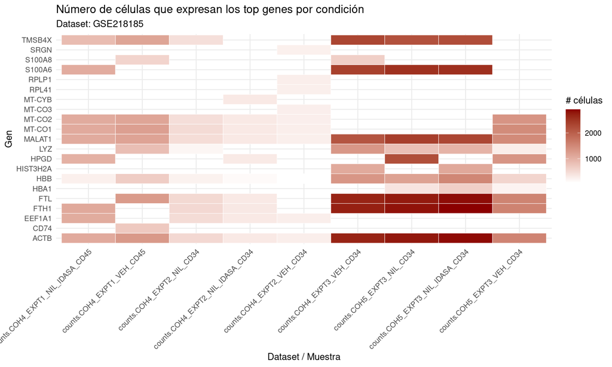

**Figura 3**.Distribución celular de los transcritos globales más abundantes. Mapa de calor (heatmap) que ilustra el número de células individuales con expresión detectable (UMIs > 0) para los genes con mayor cantidad de lecturas absolutas en el dataset. Las columnas representan cada una de las 9 réplicas biológicas evaluadas, mientras que las filas conforman el panel consolidado de los genes Top 10 más expresados por muestra. La intensidad del color es proporcional a la cantidad de células que expresan el gen..

```r
library(reshape2)

df_expr <- do.call(rbind, lapply(names(expr_cells), function(name) {
  data.frame(
    dataset = name,
    gene    = names(expr_cells[[name]]),
    cells   = expr_cells[[name]]
  )
}))

df_top <- do.call(rbind, lapply(names(top_genes), function(name) {
  genes <- names(top_genes[[name]])
  data.frame(
    dataset = name,
    gene    = genes,
    cells   = expr_cells[[name]][genes]
  )
}))

ggplot(df_top, aes(x = dataset, y = gene, fill = cells)) +
  geom_tile(color = "white") +
  scale_fill_gradient(low = "white", high = "darkred") +
  theme_minimal() +
  labs(
    title = "Número de células que expresan los top genes por condición",
    subtitle = "Dataset: GSE218185",
    x = "Dataset / Muestra",
    y = "Gen",
    fill = "# células"
  ) +
  theme(axis.text.x = element_text(angle = 45, hjust = 1))
```

**Interpretación biológica de los transcritos dominantes**

Al evaluar los genes más abundantes y su distribución celular en el mapa de calor, se identifican puede concluir lo siguiente:

2. **Influencia del microambiente (Médula Ósea):** Se visualiza una dominancia de genes eritroides (como la hemoglobina y ferritina) en casi todas las muestras es una firma biológica esperada, ya que refleja el nicho anatómico de donde se extrajeron las células.

3. **Genes ubicuos y la necesidad de control técnico:** Por otro lado, se observan transcritos constitutivos (estructurales) y de fuerte retención nuclear, como el lncRNA **MALAT1**, por lo que es necesario tenerlo en cuenta para descartar que las señales provengan de células lisadas.

# 14 Análisis del lncRNA MALAT1

El gen *MALAT1* (*Metastasis Associated Lung Adenocarcinoma Transcript 1*), también conocido como *NEAT2*, codifica para un ARN largo no codificante (lncRNA) que se localiza en los dominios nucleares denominados *speckles*. Su función principal se centra en la regulación de la expresión génica a nivel de splicing y transcripción.

MALAT1 se utiliza como biomarcador de calidad técnica, ya que al ser un transcrito de retención nuclear, un exceso de sus lecturas (típicamente >20% de los UMIs totales de una célula) sugiere que la membrana celular sufrió una lisis parcial durante el procesamiento.

## 14.1 Porcentaje de UMIs de MALAT1 por célula

```r
malat1_percent <- lapply(cell_counts, function(mat) {
  if ("MALAT1" %in% rownames(mat)) {
    gene_counts  <- mat["MALAT1", ]
    total_counts <- colSums(mat)
    100 * gene_counts / total_counts
  } else {
    warning("MALAT1 no encontrado en esta muestra")
    NULL
  }
})
```

## 14.2 Células con >20% de UMIs de MALAT1

```r
malat1_summary <- lapply(malat1_percent, function(pct) {
  if (is.null(pct)) return(NULL)
  total_cells  <- length(pct)
  cells_above  <- sum(pct > 20)
  percent_cells <- 100 * cells_above / total_cells
  list(
    total_cells   = total_cells,
    cells_above   = cells_above,
    percent_cells = round(percent_cells, 2)
  )
})

malat1_summary
```

```
$counts.COH4_EXPT1_VEH_CD45
$counts.COH4_EXPT1_VEH_CD45$total_cells
[1] 1325

$counts.COH4_EXPT1_VEH_CD45$cells_above
[1] 8

$counts.COH4_EXPT1_VEH_CD45$percent_cells
[1] 0.6


$counts.COH4_EXPT1_NIL_IDASA_CD45
$counts.COH4_EXPT1_NIL_IDASA_CD45$total_cells
[1] 1107

$counts.COH4_EXPT1_NIL_IDASA_CD45$cells_above
[1] 10

$counts.COH4_EXPT1_NIL_IDASA_CD45$percent_cells
[1] 0.9


$counts.COH4_EXPT2_VEH_CD34
$counts.COH4_EXPT2_VEH_CD34$total_cells
[1] 285

$counts.COH4_EXPT2_VEH_CD34$cells_above
[1] 3

$counts.COH4_EXPT2_VEH_CD34$percent_cells
[1] 1.05


$counts.COH4_EXPT2_NIL_CD34
$counts.COH4_EXPT2_NIL_CD34$total_cells
[1] 540

$counts.COH4_EXPT2_NIL_CD34$cells_above
[1] 2

```

[output cut: 42 more lines]

```
[1] 9

$counts.COH5_EXPT3_NIL_CD34$percent_cells
[1] 0.32


$counts.COH5_EXPT3_NIL_IDASA_CD34
$counts.COH5_EXPT3_NIL_IDASA_CD34$total_cells
[1] 2915

$counts.COH5_EXPT3_NIL_IDASA_CD34$cells_above
[1] 4

$counts.COH5_EXPT3_NIL_IDASA_CD34$percent_cells
[1] 0.14
```

## 14.3 Porcentaje global

```r
total_cells_all <- sum(sapply(malat1_summary, function(x) if (!is.null(x)) x$total_cells else 0))
cells_above_all <- sum(sapply(malat1_summary, function(x) if (!is.null(x)) x$cells_above else 0))
percent_global  <- 100 * cells_above_all / total_cells_all

cat("Porcentaje global de células con MALAT1 > 20% de UMIs:", round(percent_global, 2), "%\n")
```

```
Porcentaje global de células con MALAT1 > 20% de UMIs: 0.7 %
```

La evaluación de los niveles de *MALAT1* a lo largo de las 9 réplicas biológicas a nivel general, únicamente el **0.7%** del total de las células supera el umbral crítico del 20% de UMIs dedicados a *MALAT1*, por lo que, el dataset está libre de sesgos técnicos por daño de membrana y en condiciones óptimas para las fases de reducción de dimensionalidad (PCA).

# 15 Normalización de los datos

La normalización con `NormalizeData()` aplica la normalización estándar de Seurat: para cada célula, divide el conteo de cada gen entre el total de conteos de esa célula, multiplica por un factor de escala (10,000 por defecto, y luego aplica una transformación logarítmica (`log1p`). Esto corrige por diferencias en profundidad de secuenciación entre células.

En el estudio se menciona específicamente que se procesaron los datos con Cell Ranger seguido de Seurat con `LogNormalize` y `scale.factor = 10000`, exactamente el default de `NormalizeData()`.

```r
pbmc <- NormalizeData(data.filt, verbose = FALSE)

# Verificar que ahora tenemos la capa 'data' (normalizada) además de 'counts'
Layers(pbmc, assay = "RNA")
```

```
 [1] "counts.COH4_EXPT1_VEH_CD45"       "counts.COH4_EXPT1_NIL_IDASA_CD45"
 [3] "counts.COH4_EXPT2_VEH_CD34"       "counts.COH4_EXPT2_NIL_CD34"
 [5] "counts.COH4_EXPT2_NIL_IDASA_CD34" "counts.COH4_EXPT3_VEH_CD34"
 [7] "counts.COH5_EXPT3_VEH_CD34"       "counts.COH5_EXPT3_NIL_CD34"
 [9] "counts.COH5_EXPT3_NIL_IDASA_CD34" "data.COH4_EXPT1_VEH_CD45"
[11] "data.COH4_EXPT1_NIL_IDASA_CD45"   "data.COH4_EXPT2_VEH_CD34"
[13] "data.COH4_EXPT2_NIL_CD34"         "data.COH4_EXPT2_NIL_IDASA_CD34"
[15] "data.COH4_EXPT3_VEH_CD34"         "data.COH5_EXPT3_VEH_CD34"
[17] "data.COH5_EXPT3_NIL_CD34"         "data.COH5_EXPT3_NIL_IDASA_CD34"
```

# 16 Guardar el objeto Seurat

Una vez que guardamos el objeto, el cual contiene:

1. `counts` — datos crudos
2. `data` — datos normalizados
3. `metadata` — datos de QC

Tenemos lo necesario para los siguientes análisis: selección de genes variables, reducción de dimensionalidad (PCA), UMAP, y clustering

```r
if (!dir.exists("output")) dir.create("output")

saveRDS(pbmc, file = "output/GSE218185_CML_normalized.rds")
cat("Objeto guardado en: output/GSE218185_CML_normalized.rds\n")
```

```
Objeto guardado en: output/GSE218185_CML_normalized.rds
```

```r
cat("El objeto contiene:\n")
```

```
El objeto contiene:
```

```r
cat("  - Células totales:", ncol(pbmc), "\n")
```

```
  - Células totales: 13647
```

```r
cat("  - Genes totales:", nrow(pbmc), "\n")
```

```
  - Genes totales: 17861
```

```r
cat("  - Capas disponibles:", paste(Layers(pbmc), collapse = ", "), "\n")
```

```
  - Capas disponibles: counts.COH4_EXPT1_VEH_CD45, counts.COH4_EXPT1_NIL_IDASA_CD45, counts.COH4_EXPT2_VEH_CD34, counts.COH4_EXPT2_NIL_CD34, counts.COH4_EXPT2_NIL_IDASA_CD34, counts.COH4_EXPT3_VEH_CD34, counts.COH5_EXPT3_VEH_CD34, counts.COH5_EXPT3_NIL_CD34, counts.COH5_EXPT3_NIL_IDASA_CD34, data.CO…
```

# 17 Selección de Genes Altamente Variables (HVG)

De los 17,861 genes que se obtuvieron del dataset, la mayoría no varía significativamente entre células y solo nos generaría ruido a nuestro análisis. En Seurat, `FindVariableFeatures()` permite identificar los 2,000 genes con mayor variabilidad biológica entre células usando el método `vst` (variance-stabilizing transformation), que modela la relación media-varianza y con ello, nos ayudaría a seleccionar los genes que se desvían más de lo esperado por azar.

Además, el paper menciona explícitamente: *“we used the top 2000 most highly variable genes as PCA features for dimensionality reduction”* (Scott et al., 2024). Estos 2,000 genes serán la base para PCA, UMAP y clustering. Se espera que genes clave del ESC-REG como TP53, MKI67, y genes ribosomales como RPL19 y RPS2 estén entre los HVG.

```r
pbmc <- FindVariableFeatures(
  pbmc,
  selection.method = "vst", # metodo
  nfeatures        = 2000,  # 2,000 genes con mayor variabilidad
  verbose          = FALSE
)

# observamos los 10 genes más variables
top10_hvg <- head(VariableFeatures(pbmc), 10)
cat("Top 10 HVG:\n")
```

```
Top 10 HVG:
```

```r
print(top10_hvg)
```

```
 [1] "HIST3H2A" "HLA-DRB1" "HLA-DQB1" "CD74"     "ATF3"     "MAML2"
 [7] "HMBS"     "ALAD"     "CSF2"     "MT1M"
```

```r
# genes clave del paper están entre los HVG???
genes_paper <- c("TP53", "MKI67", "CD38", "MALAT1", "RPL19", "RPS2",
                 "FOS", "DUSP1", "ZFP36", "HBA1", "HBA2")
genes_en_hvg <- genes_paper[genes_paper %in% VariableFeatures(pbmc)]
cat("\nGenes del paper presentes entre los HVG:\n")
```

```
Genes del paper presentes entre los HVG:
```

```r
print(genes_en_hvg)
```

```
[1] "RPL19" "RPS2"  "FOS"   "DUSP1" "ZFP36" "HBA1"  "HBA2"
```

El gráfico de HVG muestra en rojo a los 2,000 genes seleccionados que concentran la mayor variabilidad biológica del dataset y que serán usados como input para el PCA.

- Los HVG se distribuyen a lo largo de todo el rango de expresión promedio, lo que indica que la selección de genes moderadamente expresados como de genes de alta expresión con variabilidad real.
- Los genes más variables destacan marcadores de relevancia para el contexto del paper: CD74 y los genes HLA-DRB1 y HLA-DQB1 están relacionados con el linaje NMM (neutrófilo/monocito/macrófago) que el paper reporta como depletado con NIL+IDASA.

```r
# graficar genes variables vs no variables
plot_hvg <- VariableFeaturePlot(pbmc)

# etiquetar los 10 más variables
plot_hvg_labeled <- LabelPoints(
  plot   = plot_hvg,
  points = top10_hvg,
  repel  = TRUE
)
```

```
When using repel, set xnudge and ynudge to 0 for optimal results
```

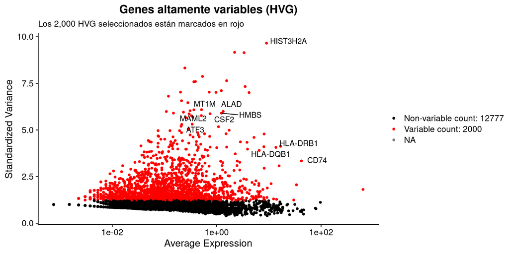

**Figura 4**. Selección de genes altamente variables (HVG). Los 2,000 genes seleccionados se muestran en rojo; los genes no variables se muestran en negro.Se etiquetan los 10 genes con mayor varianza estandarizada. Se identificaron genes de relevancia biológica entre los HVG, incluyendo HIST3H2A (regulación de cromatina), CSF2 (factor estimulante de colonias, relevante en diferenciación mieloide), CD74 y HLA-DRB1/HLA-DQB1 (presentación de antígenos, linaje NMM), ATF3 (respuesta a estrés), y MAML2 (señalización Notch)

```r
plot_hvg_labeled +
  labs(
    title    = "Genes altamente variables (HVG)",
    subtitle = "Los 2,000 HVG seleccionados están marcados en rojo"
  )
```

# 18 Escalado de los datos

El siguiente paso es sumamente importante antes de visualizar el PCA, para evitar que genes con mayor expresión absoluta no dominen el análisis independientemente de su variabilidad biológica (por ejemplo, genes como MALAT1 o genes de hemoglobina, que tienen conteos muy altos, dominarían los componentres principales aunque no sean los más informativos). El método utilizado es `ScaleData()`, que realiza un z-score por gen, centra la expresión de cada gen en cero y normaliza la varianza a 1.

```r
# escalamos únicamente los HVG
pbmc <- ScaleData(
  pbmc,
  features = VariableFeatures(pbmc),
  verbose  = FALSE
)

cat("Capas disponibles tras el escalado:\n")
```

```
Capas disponibles tras el escalado:
```

```r
print(Layers(pbmc, assay = "RNA"))
```

```
 [1] "counts.COH4_EXPT1_VEH_CD45"       "counts.COH4_EXPT1_NIL_IDASA_CD45"
 [3] "counts.COH4_EXPT2_VEH_CD34"       "counts.COH4_EXPT2_NIL_CD34"
 [5] "counts.COH4_EXPT2_NIL_IDASA_CD34" "counts.COH4_EXPT3_VEH_CD34"
 [7] "counts.COH5_EXPT3_VEH_CD34"       "counts.COH5_EXPT3_NIL_CD34"
 [9] "counts.COH5_EXPT3_NIL_IDASA_CD34" "data.COH4_EXPT1_VEH_CD45"
[11] "data.COH4_EXPT1_NIL_IDASA_CD45"   "data.COH4_EXPT2_VEH_CD34"
[13] "data.COH4_EXPT2_NIL_CD34"         "data.COH4_EXPT2_NIL_IDASA_CD34"
[15] "data.COH4_EXPT3_VEH_CD34"         "data.COH5_EXPT3_VEH_CD34"
[17] "data.COH5_EXPT3_NIL_CD34"         "data.COH5_EXPT3_NIL_IDASA_CD34"
[19] "scale.data"
```

# 19 Reducción de dimensionalidad — PCA

El PCA (Análisis de Componentes Principales) comprime la información de los 2,000 HVG en un espacio de menor dimensión que captura la mayor varianza. Los primeros componentes capturan la mayor variación biológica: diferencias entre tipos celulares, entre condiciones de tratamiento, y potencialmente podríamos observar efectos batch.

```r
pbmc <- RunPCA(
  pbmc,
  features = VariableFeatures(pbmc),
  npcs     = 50,         # calculamos 50 para el elbow plot
  verbose  = FALSE
)

# Resumen de los primeros 5 PCs
print(pbmc[["pca"]], dims = 1:5, nfeatures = 5)
```

```
PC_ 1
Positive:  HPGD, TPSAB1, TPSB2, CPA3, HPGDS
Negative:  CORO1A, LYZ, HMGB2, ALDH2, TKT
PC_ 2
Positive:  PHOSPHO1, MXD1, GDA, YPEL3, PYGL
Negative:  RPL32, RPS8, RPS28, RPL19, EEF1A1
PC_ 3
Positive:  TMSB10, S100A11, TMSB4X, TYROBP, FOS
Negative:  GLRX5, PRDX2, CA2, ALAS2, HBA1
PC_ 4
Positive:  HLA-DPB1, SAMHD1, CD74, LSP1, HLA-DRB5
Negative:  HPGD, TPSAB1, TPSB2, ANXA1, CPA3
PC_ 5
Positive:  LGMN, SELENOP, TF, MAFB, CKB
Negative:  TOP2A, LST1, CDK1, BIRC5, HLA-B
```

## 19.1 ¿Cuántos componentes usar? — ElbowPlot

El *elbow plot* muestra la varianza explicada por cada componente principal, se puede observar caída en los primeros 10 PCs, seguida de un descenso hasta ~PC 25, donde la curva se estabiliza en valores de desviación estándar menores a 2. Se seleccionaron los primeros **25 componentes principales** como dimensiones de entrada para Harmony y UMAP, con el objetivo de capturar la variación biológica de poblaciones minoritarias (como LSC quiescentes) y excluir ruido técnico.

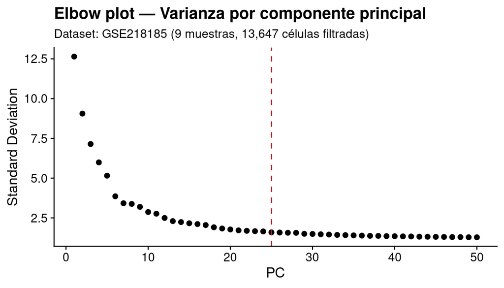

**Figura 5**. Elbow plot de los componentes principales. Cada punto representa la desviación estándar explicada por cada PC. La curva muestra un codo aproximado en PC 20-25, lo que sugiere que los primeros 25 PCs capturan la mayor parte de la variación biológica relevante. La línea punteada indica el umbral seleccionado (PC = 25).

```r
ElbowPlot(pbmc, ndims = 50) +
  geom_vline(xintercept = 25, linetype = "dashed", color = "firebrick") +
  labs(
    title    = "Elbow plot — Varianza por componente principal",
    subtitle = "Dataset: GSE218185 (9 muestras, 13,647 células filtradas)"
  )
```

## 19.2 Vizualización del PCA

De los tres paneles del PCA podemos decir lo siguiente:

Al observar los paneles es suficiente para justificar el uso de Harmony para corrección de batch antes del clustering, usando el experimento de captura como variable de corrección.

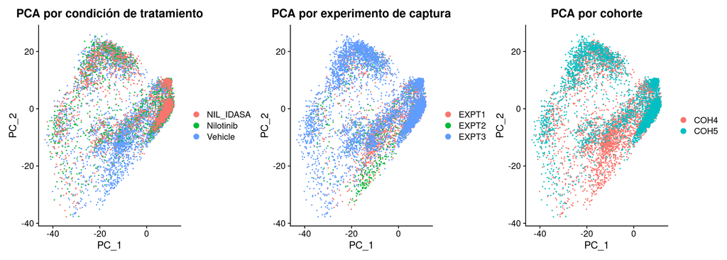

**Figura 6**. Análisis de Componentes Principales (PCA) previo a la corrección de batch. Visualización de los dos primeros componentes principales (PC1 y PC2) coloreados por condición de tratamiento (izquierda), experimento de captura (centro) y cohorte de ratones PDX (derecha). Se observa una clara separación estructural del espacio de PCA asociada a variables técnicas, indicando la presencia de efecto batch que requiere corrección antes del clustering.

```r
p1 <- DimPlot(pbmc, reduction = "pca", group.by = "condition") +
  labs(title = "PCA por condición de tratamiento")

p2 <- DimPlot(pbmc, reduction = "pca", group.by = "experiment") +
  labs(title = "PCA por experimento de captura")

p3 <- DimPlot(pbmc, reduction = "pca", group.by = "cohort") +
  labs(title = "PCA por cohorte")

p1 | p2 | p3
```

# 20 Corrección de batch — Harmony

El dataset presenta tres fuentes de variación técnica, lo cual se puede confundir con diferencias biológicas reales

1. **Experimento de captura** (EXPT1, EXPT2, EXPT3): capturas independientes en el Chromium 10X en distintos momentos.
2. **Cohorte de ratones** (COH4, COH5): grupos de ratones procesados en distintos momentos (fin de tratamiento vs período libre)
3. **Plataforma de secuenciación**: HiSeq 4000 (EXPT1/EXPT2) vs NovaSeq 6000 (EXPT3).

Sin corrección, las células podrían agruparse por experimento en lugar de por tipo celular o condición biológica, para ello usamos Harmony (Korsunsky et al., 2019), un algoritmo de integración que ajusta el espacio PCA para minimizar la variación asociada a variables técnicas y conservando la variación biológica real, sin modificar los datos originales o la normalización.

```r
library(harmony)

pbmc <- RunHarmony(
  object = pbmc,
  group.by.vars = "experiment", # variable de batch a corregir
  reduction.use = "pca",
  dims.use = 1:25,
  verbose = FALSE
)

cat("Reducción Harmony calculada. Dimensiones disponibles:\n")
```

```
Reducción Harmony calculada. Dimensiones disponibles:
```

```r
print(names(pbmc@reductions))
```

```
[1] "pca"     "harmony"
```

## 20.1 Comparar PCA antes y después de Harmony

Esto podría interpretarse como fallo de la corrección. Sin embargo, al cruzar con la variable de tipo celular, esta separación refleja una diferencia biológica real entre las células huCD45+ (EXPT1) y las células huCD34+ (EXPT2 y EXPT3); son poblaciones transcriptómicamente distintas que no deben mezclarse. Harmony integró las muestras CD34+ entre EXPT2 y EXPT3, que sí comparten tipo celular.

Esta es una limitación metodológica del análisis conjunto, al integrar huCD45+ y huCD34+ en un solo objeto antes de Harmony, la corrección de batch opera sobre un espacio mixto donde parte de la variación que parece técnica es en realidad biológica. Un análisis más riguroso aplicaría Harmony de forma independiente sobre cada población celular, separando primero CD34+ y CD45+ y corrigiendo el batch dentro de cada grupo.

Posteriormente en la anotación celular se confirma que la corrección aplicada fue suficiente.

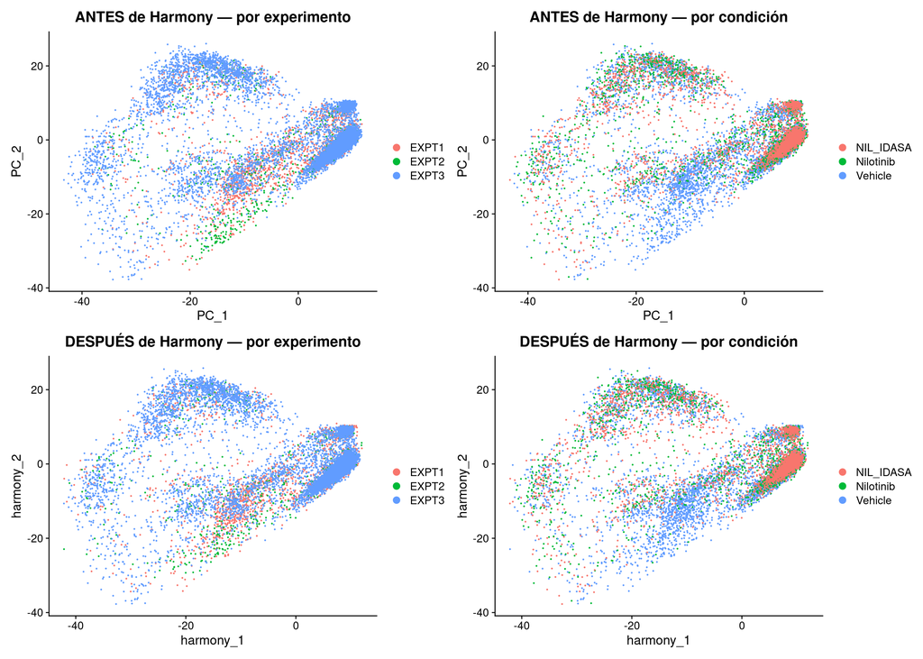

**Figura 7**.Comparación del espacio de embedding antes y después de la corrección de batch con Harmony. Fila superior: proyección de los primeros dos componentes del PCA crudo, coloreados por experimento de captura (izquierda) y por condición de tratamiento (derecha). Fila inferior: proyección de los primeros dos embeddings de Harmony tras la corrección, coloreados por experimento (izquierda) y por condición (derecha).

```r
p_before1 <- DimPlot(pbmc, reduction = "pca",     group.by = "experiment") +
  labs(title = "ANTES de Harmony — por experimento")
p_before2 <- DimPlot(pbmc, reduction = "pca",     group.by = "condition") +
  labs(title = "ANTES de Harmony — por condición")

p_after1  <- DimPlot(pbmc, reduction = "harmony",  group.by = "experiment") +
  labs(title = "DESPUÉS de Harmony — por experimento")
p_after2  <- DimPlot(pbmc, reduction = "harmony",  group.by = "condition") +
  labs(title = "DESPUÉS de Harmony — por condición")

(p_before1 | p_before2) / (p_after1 | p_after2)
```

# 21 UMAP

Es importante notar que el UMAP (Uniform Manifold Approximation and Projection) se construye sobre los embeddings de Harmony (ya corregidos), no sobre el PCA original.El UMAP, nos permite comprimir el espacio de alta dimensión en 2D para una mejor visualización, ademas preserva mejor los agrupamientos de células similares.

El clustering se hará también sobre Harmony.

```r
pbmc <- RunUMAP(
  pbmc,
  reduction = "harmony", # usar Harmony corregido, no PCA crudo
  dims      = 1:25,
  verbose   = FALSE,
  seed.use  = 42    # reproducibilidad
)
```

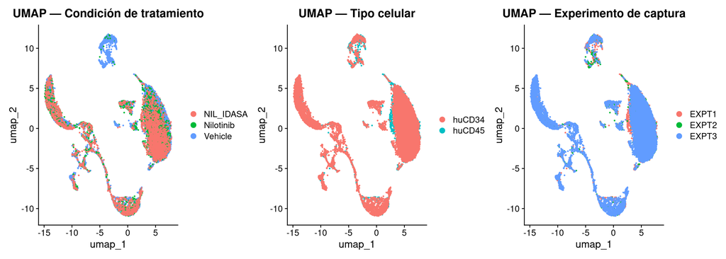

**Figura 8**. Proyección UMAP del dataset completo tras la corrección de efecto de lote con Harmony. Panel izquierdo: coloreado por condición de tratamiento (VEH = azul, NIL = verde, NIL+IDASA = rojo). Panel central: coloreado por tipo celular aislado (huCD45+ vs huCD34+). Panel derecho: coloreado por experimento de captura (EXPT1, EXPT2, EXPT3). La corrección con Harmony permite que células del mismo tipo se agrupen independientemente del experimento de captura.

```r
p1 <- DimPlot(pbmc, reduction = "umap", group.by = "condition",  pt.size = 0.3) +
  labs(title = "UMAP — Condición de tratamiento")

p2 <- DimPlot(pbmc, reduction = "umap", group.by = "cell_type",  pt.size = 0.3) +
  labs(title = "UMAP — Tipo celular")

p3 <- DimPlot(pbmc, reduction = "umap", group.by = "experiment", pt.size = 0.3) +
  labs(title = "UMAP — Experimento de captura")

p1 + p2 + p3
```

# 22 Clustering — identificación de poblaciones celulares

El clustering se realiza sobre el grafo de vecinos más cercanos (KNN) construido a partir del espacio de Harmony. El algoritmo de Louvain asigna células a comunidades basándose en la densidad de conexiones. Mientras que el parámetro `resolution` controla la granularidad, es decir, valores más altos producen más clusters, valores más bajos producen menos.

En el paper se reportan clusters anotados como tipos mieloides maduros, progenitores y LSC (ESC-REG), lo que sugiere una resolución moderada (~0.5).

```r
# Paso 1: grafo KNN
pbmc <- FindNeighbors(
  pbmc,
  reduction = "harmony",
  dims      = 1:25,
  k.param   = 20,
  verbose   = FALSE
)

# Paso 2: clustering con Louvain
pbmc <- FindClusters(
  pbmc,
  resolution   = 0.5,
  algorithm    = 1,    # 1 = Louvain (paper original)
  random.seed  = 42,
  verbose      = FALSE
)

cat("Número de clusters identificados:", length(unique(pbmc$seurat_clusters)), "\n")
```

```
Número de clusters identificados: 18
```

```r
table(pbmc$seurat_clusters)
```

```
   0    1    2    3    4    5    6    7    8    9   10   11   12   13   14   15
3938 3434  949  919  848  596  423  421  402  336  325  321  220  146  126  109
  16   17
  68   66
```